# Analysing real catch and effort data: a step-by-step guide

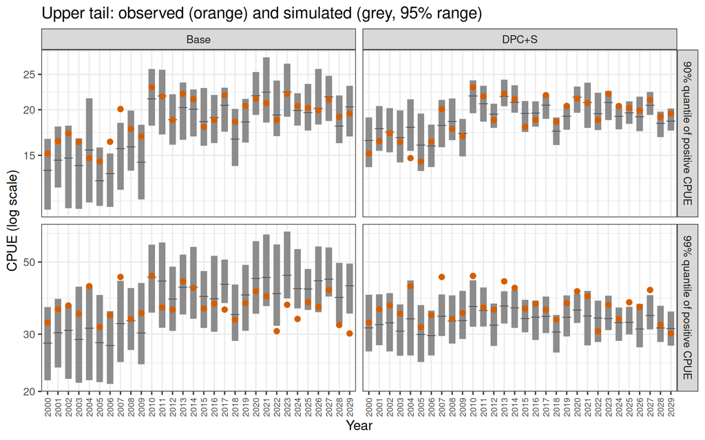

```r
pp$plots$tails
```

How to read it:

- **Zeros** observed above the envelope: the model predicts too few zeros (e.g. a Poisson-type or lognormal-type error); below: too many.
- **Upper quantiles** observed below the envelope: the model’s tail is too heavy (e.g. a negative binomial or a lognormal with large variance); above: too light.
- **Histogram of CPUE, zeros included** (`pp$plots$distribution`): observed bars (the zero bar leftmost) against the predictive distribution (points with 95% ranges). Systematic departures point to the wrong distribution or power parameter. CPUE spans orders of magnitude, so the histogram is on a fourth-root scale by default (zero stays next to the small catches); `scale = "log"` shows the shape of the positive catches best, with the zeros as a separate bar, and `scale = "raw"` the untransformed values.
- **By year.** Pooled over all operations, errors in opposite directions can cancel. The year effect fixes the mean CPUE of each year, not its zeros: a model without targeting covariates gives every operation in a year the same expected catch and gets the zeros wrong in years when the fleet fished elsewhere. A good targeting term brings the observed zeros inside the envelope. Other groupings: `by = "FT"`, `by = "month"`.
- `tail_prob` is the share of replicates at least as large as the observed value; values near 0 or 1 flag misfit.
- Information criteria cannot compare a Tweedie with a delta model; a predictive check can.

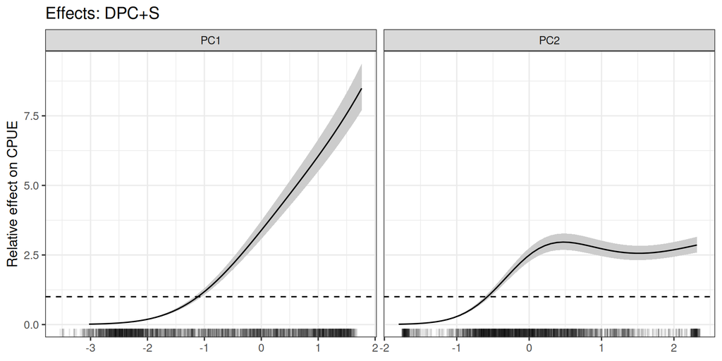

```r
eff <- plot_effects(fit, "DPC+S")
eff$numeric
```

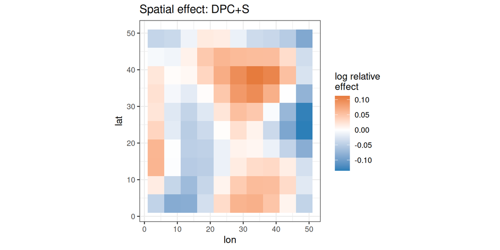

```r
eff$space
```

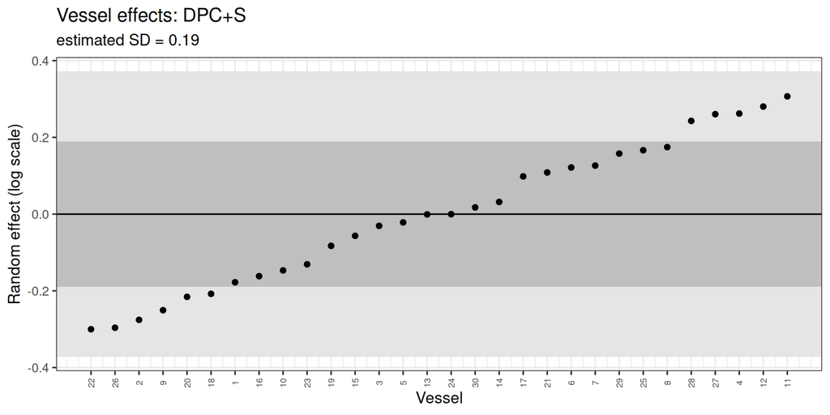

```r
plot_vessel_effects(fit, "DPC+S")
```

> **Guidelines**
> - Check the **influence** of the targeting terms: a strong trend in influence means targeting changed and the term corrects for it.
> - Check that residuals show **no trend by year** and no pattern against the targeting covariates or tactics.
> - Check that the error distribution reproduces the **zeros and the upper tail by year** (`ppc_cpue()`).
> - Compare the **DPC and Cluster** indices. If they disagree, look at what the PCs capture over time (Step 6) and whether the species’ relative abundances may have diverged.

## Step 9. The final index

```r
cpue_index(fit, "DPC+S")
```

```
##    year   n  nominal    index  relative     se_log         cv     lower
## 1  2000 240 4.510639 7.799805 1.0211187 0.05723977 0.05728669 0.9127519
## 2  2001 341 5.015292 8.000362 1.0473748 0.05119003 0.05122359 0.9473889
## 3  2002 278 4.842745 8.325937 1.0899977 0.05467163 0.05471251 0.9792378
## 4  2003 266 4.580052 7.820604 1.0238416 0.05604453 0.05608857 0.9173323
## 5  2004 193 5.362843 7.928239 1.0379327 0.06021755 0.06027218 0.9223824
## 6  2005 285 4.500457 7.704467 1.0086373 0.05456156 0.05460220 0.9063403
## 7  2006 347 4.314219 8.127375 1.0640027 0.05265772 0.05269425 0.9596648
## 8  2007 413 5.213270 8.000547 1.0473990 0.04979724 0.04982812 0.9500006
## 9  2008 329 5.567656 7.800039 1.0211493 0.05097000 0.05100312 0.9240654
## 10 2009 391 4.924253 7.903036 1.0346332 0.04996733 0.04999854 0.9381092
## 11 2010 394 7.885983 8.275977 1.0834572 0.04696518 0.04699109 0.9881757
## 12 2011 315 7.431699 7.991093 1.0461612 0.04932446 0.04935447 0.9497576
## 13 2012 477 6.431612 7.435989 0.9734893 0.04580820 0.04583224 0.8898944
## 14 2013 439 7.263159 8.394664 1.0989952 0.04631051 0.04633535 1.0036342
```

[output cut: 47 more lines]

```r
export_index(fit, "cpue_index_DPC.csv", model = "DPC+S")
```

`index` is in the units of the data (CPUE at the reference covariate values), `relative` is scaled to its mean, and `se_log` is the standard error of the log index, the usual input to stock assessment models.

### Input for assessment models

The standardised indices can be passed directly to surplus production models. `index_set()` collects one or several indices (models of one fit, or a named list of fits for scenarios), optionally restricted to a range of years and normalised to mean 1; the exporters build the input of each model from it:

- `as_jabba()`: the `cpue` and `se` data frames of JABBA (`JABBA::build_jabba()`), also accepted by JABBA3 (`JABBA3::jb3_data()`);
- `as_FLIndexBiomass()` / `as_FLIndices()`: FLR objects (package `FLCore`, suggested) with the log SE in `index.var`, the native index input of JABBA3; several series give a named `FLIndices`;
- `as_spict()`: `obsI`, `timeI` and `stdevfacI` for SPiCT, with a prior on the observation SD of each index in `priors$logsdi`;
- `as_ss3()`: the CPUE block of a Stock Synthesis data file (`#_yr`, `month`, `fleet`, `obs`, `stderr`, `#_` comment), with excluded years as negative years.

```r
jb <- as_jabba(fit, model = c("Cluster+S", "DPC+S"), normalise = TRUE)
head(jb$cpue)
```

```
##   year Cluster+S    DPC+S
## 1 2000 0.9320355 1.021119
## 2 2001 0.9400433 1.047375
## 3 2002 1.0988357 1.089998
## 4 2003 0.9656093 1.023842
## 5 2004 0.9287616 1.037933
## 6 2005 0.9477603 1.008637
```

```r
head(jb$se)
```

```
##   year  Cluster+S      DPC+S
## 1 2000 0.07366987 0.05723977
## 2 2001 0.06424672 0.05119003
## 3 2002 0.06951106 0.05467163
## 4 2003 0.07097953 0.05604453
## 5 2004 0.07823038 0.06021755
## 6 2005 0.06905820 0.05456156
```

```r
si <- as_spict(fit, model = "DPC+S", timing = 0.5)
str(si)
```

```
## List of 5
##  $ obsI     :List of 1
##   ..$ DPC+S: num [1:30] 7.8 8 8.33 7.82 7.93 ...
##  $ timeI    :List of 1
##   ..$ DPC+S: num [1:30] 2000 2002 2002 2004 2004 ...
##  $ stdevfacI:List of 1
##   ..$ DPC+S: num [1:30] 1.18 1.06 1.13 1.16 1.24 ...
##  $ priors   :List of 1
##   ..$ logsdi: num [1:3] -3.03 0.5 1
##  $ sdI      : Named num 0.0484
##   ..- attr(*, "names")= chr "DPC+S"
```

```r
ss3 <- as_ss3(fit, model = c("Cluster+S", "DPC+S"), fleet = c(3, 4), month = 7)
head(ss3)
```

```
##   #_yr month fleet      obs     stderr      comment
## 1 2000     7     3 4.163222 0.07366987 #_ Cluster+S
## 2 2001     7     3 4.198991 0.06424672 #_ Cluster+S
## 3 2002     7     3 4.908286 0.06951106 #_ Cluster+S
## 4 2003     7     3 4.313189 0.07097953 #_ Cluster+S
## 5 2004     7     3 4.148597 0.07823038 #_ Cluster+S
## 6 2005     7     3 4.233461 0.06905820 #_ Cluster+S
```

```r
# write.csv(ss3, "ss3idx.csv", row.names = FALSE, quote = FALSE)
```

```r
fl <- as_FLIndices(fit, model = c("Cluster+S", "DPC+S"), normalise = TRUE)
fl
```

```
## An object of class "FLIndices"
## [[1]]
## An object of class "FLIndexBiomass"
##
## Name: Cluster+S
## Description:
## Distribution :  lognormal
## Quant: age
## Dims:  age   year    unit    season  area    iter
##  1   30  1   1   1   1
##
## Range:  min  max pgroup  minyear maxyear startf  endf
##  NA  NA  NA  2000    2029    NA  NA
##
##
## [[2]]
## An object of class "FLIndexBiomass"
##
## Name: DPC+S
## Description:
## Distribution :  lognormal
## Quant: age
## Dims:  age   year    unit    season  area    iter
##  1   30  1   1   1   1
##
## Range:  min  max pgroup  minyear maxyear startf  endf
##  NA  NA  NA  2000    2029    NA  NA
##
##
## Slot "names":
## [1] "Cluster+S" "DPC+S"
##
## Slot "desc":
## character(0)
##
## Slot "lock":
## [1] FALSE
```

```r
# JABBA3 with FLR inputs (catch as FLQuant) or the JABBA data frames
d <- JABBA3::jb3_data(catch, fl, index.time = 0.5)
d <- JABBA3::jb3_data(catch_df, jb$cpue, jb$se)
# SPiCT
inp <- list(obsC = catch_df$catch, timeC = catch_df$year)
inp[c("obsI", "timeI", "stdevfacI")] <- si[c("obsI", "timeI", "stdevfacI")]
inp$priors$logsdi <- si$priors$logsdi
spict_fit <- spict::fit.spict(inp)
```

## Processing log

The log records every step, how many operations it removed, and the settings used.

```r
x$log
```

```
##                                         step operations
## 1                        input (long format)      12799
## 2                             select species      12799
## 3 remove operations without selected species      12798
## 4                              add targeting      12798
##                                                           note
## 1                                     44049 records, 6 species
## 2                     4 of 6 species kept (occurrence >= 0.95)
## 3               zero catch of all selected species (1 removed)
## 4 2 PC(s) used (OC test: 2), 3 clusters (clara on composition)
```

## Reporting checklist

| Item | Report |
| --- | --- |
| Operation and effort | unit (set, trip, …), effort measure |
| Data selection | all subsetting rules and the processing log |
| Species set | threshold, criterion (occurrence or weight), species kept |
| Fleet | indicator-fleet rules (activity and target species), number of vessels |
| Subsetting | Stephens & MacCall target, critical value, share kept over time; tactics removed (`select_tactics()`) |
| Targeting | transformation, eigenvalues, OC result, number of PCs and clusters, clustering method, tactic composition |
| Models | family, terms of each model, random effects, reference set of the index |
| Diagnostics | model table, step and influence plots, residuals, predictive check (zeros and tails by year), vessel effects |
| Index | table with nominal and standardised CPUE, log SE and CV |
| Sensitivity | indices with alternative species sets, numbers of PCs, clusters, families |

## References

Bentley, N., Kendrick, T.H., Starr, P.J. and Breen, P.A. (2012) Influence plots and metrics: tools for better understanding fisheries catch-per-unit-effort standardizations. ICES Journal of Marine Science 69: 84-88.

Dunn, P.K. and Smyth, G.K. (1996) Randomized quantile residuals. Journal of Computational and Graphical Statistics 5: 236-244.

Gelman, A., Meng, X.-L. and Stern, H. (1996) Posterior predictive assessment of model fitness via realized discrepancies. Statistica Sinica 6: 733-807.

Hoyle, S.D., Langley, A.D. and Campbell, R.A. (2014) Recommended approaches for standardizing CPUE data from pelagic fisheries. WCPFC-SC10-2014/SA-IP-10.

Stephens, A. and MacCall, A. (2004) A multispecies approach to subsetting logbook data for purposes of estimating CPUE. Fisheries Research 70: 299-310.

Winker, H., Kerwath, S.E. and Attwood, C.G. (2013) Comparison of two approaches to standardize catch-per-unit-effort for targeting behaviour in a multispecies hand-line fishery. Fisheries Research 139: 118-131.

Winker, H., Kerwath, S.E. and Attwood, C.G. (2014) Proof of concept for a novel procedure to standardize multispecies catch and effort data. Fisheries Research 155: 149-159.